# Geocentric Models, Practice

Gina Nichols

6/15/2020

**I’d like to discuss M6 and M7**

### E1 Which of these is the likelihood?

$$\begin{array}{l}
y_i \sim Normal(\mu, \sigma) \\
\mu \sim Normal(0, 10) \\
\sigma \sim Exponential(1) \\
\end{array}$$

$y_i \sim Normal(\mu, \sigma)$ is the likelihood.

### E2 How many parm in prior?

There are 2 parameters in the posterior distribution, $\mu$ and $\sigma$.

### E3 Write that model using Bayes’ theorem.

Ugh. Not that good in Latex.

### E4 Which of these is the linear model?

$$\begin{array}{l}
h_i \sim Normal(\mu_i, \sigma) \\
\mu_i = \alpha + \beta (x_i - \bar{x}) \\
\alpha \sim Normal(0, 10) \\
\beta \sim Normal(0, 1) \\
\sigma \sim Exponential(2) \\
\end{array}$$

$\mu_i = \alpha + \beta (x_i - \bar{x})$ is our linear model. Although I think there is a typo in the book in the likelihood.

### E5 How many parameters are in that posterior distribution?

Three - $\alpha$, $\beta$, and $\sigma$.

### M1 Simulate observed y values from the prior for the model below:

$$\begin{array}{l}
y_i \sim Normal(\mu, \sigma) \\
\mu \sim Normal(0, 10) \\
\sigma \sim Exponential(1) \\
\end{array}$$

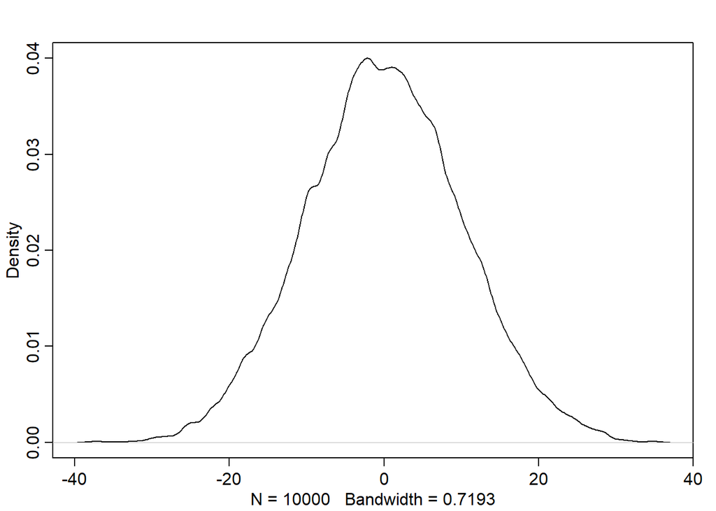

```r
sample_mu <- rnorm (1e4, 0, 10)
sample_sig <- rexp(1e4, 1)
prior_h <- rnorm(1e4, sample_mu, sample_sig)
dens(prior_h)
```

### M2 Translate this into a quap formula.

```r
flist <-
  alist(
    height ~ dnorm(mu, sigma),
    mu ~ dnorm(0, 10),
    sigma ~ dexp(1)
  )
```

### M3

This is the same as **E4**

### M4 Mathematical model for student heights over 3 years

You measure student heights over 3 years. I want a linear regression predicting height using year as a predictor. Write a mathematical model for this. Defend it!

$$\begin{array}{l}
h_i \sim Normal(\mu_i, \sigma) \\
\mu_i = \alpha + \beta (year_i - \bar{year}) \\
\alpha \sim Normal(0, 10) \\
\beta \sim LogNormal(0, 1) \\
\sigma \sim Exponential(1) \\
\end{array}$$

### M5 Think about the priors

No because I already forced the $\beta$ to be positive by using that LogNormal thing.

### M6 Update priors based on new info

I’m not sure how I’d add this information to the *exponential* distribution. In my ignorance I suppose I’d update it to:

$\sigma \sim Uniform(0, 8)$

**I’d like help on this one**

### M7 Height as function of weight, HELP

Fit m4.3 again.

```r
data(Howell1)
d2 <-
  Howell1 %>%
  filter(age >= 18)

xbar <- mean(d2$height)

hmod_cent <-
  quap(
    alist(
      height ~ dnorm(mu, sigma),
      mu <- a + b*(weight - xbar),
      a ~ dnorm(178, 20),
      b ~ dlnorm(0, 1),
      sigma ~ dunif(0, 50)
    ),
    data = d2)

precis(hmod_cent)
```

```
##             mean         sd        5.5%       94.5%
## a     249.791960 4.49924703 242.6012938 256.9826253
## b       0.868634 0.04098167   0.8031374   0.9341306
## sigma   5.077312 0.19174901   4.7708604   5.3837643
```

Hmmm. I’m not getting the same answer they got. What is wrong?

Pretend it’s fine, I guess.

```r
post_hmod_cent <- extract.samples(hmod_cent) #--get our posterior samples of a, b, and sigma

p_hmod_cent <-
  d2 %>%
  mutate(a = mean(post_hmod_cent$a),
         b = mean(post_hmod_cent$b),
         height_pred = a + b * (weight - xbar)) %>%
  ggplot(aes(weight, height)) +
  geom_point() +
  geom_line(aes(weight, height_pred), color = "green4") +
  labs(title = "Centered Model")
```

Fit it without the centering

```r
hmod <-
  quap(
    alist(
      height ~ dnorm(mu, sigma),
      mu <- a + b*(weight),
      a ~ dnorm(178, 20),
      b ~ dlnorm(0, 1),
      sigma ~ dunif(0, 50)
    ),
    data = d2)

post_hmod <- extract.samples(hmod) #--get our posterior samples of a, b, and sigma

p_hmod <-
  d2 %>%
  mutate(a = mean(post_hmod$a),
         b = mean(post_hmod$b),
         height_pred = a + b * (weight)) %>%
  ggplot(aes(weight, height)) +
  geom_point() +
  geom_line(aes(weight, height_pred), color = "red") +
  labs(title = "Un-centered Model")
```

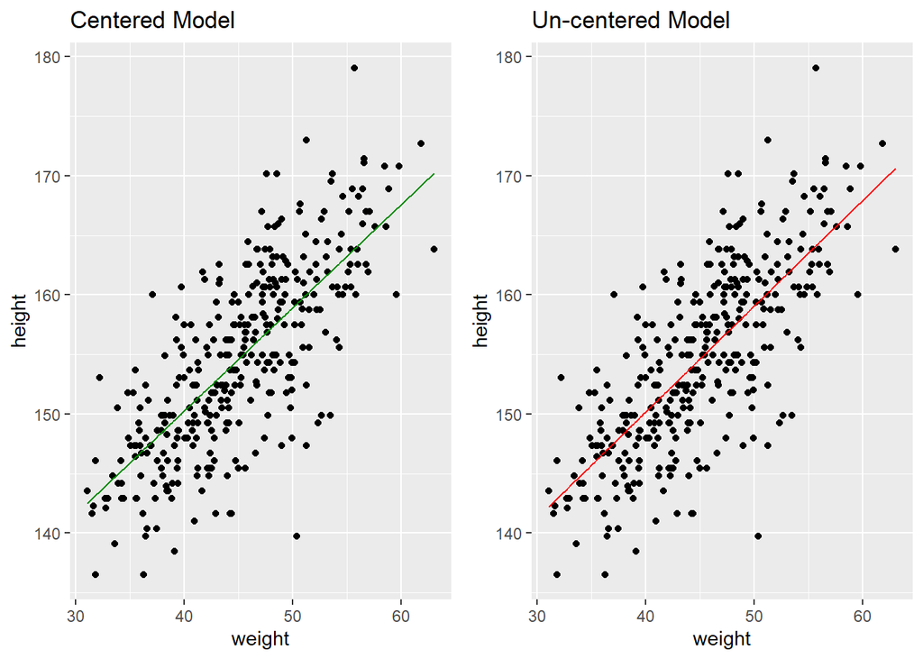

```r
library(patchwork)
p_hmod_cent + p_hmod
```

It looks identical to me. Look at the covariance, they say.

The ‘centered’ model:

```r
precis(hmod_cent)
```

```
##             mean         sd        5.5%       94.5%
## a     249.791960 4.49924703 242.6012938 256.9826253
## b       0.868634 0.04098167   0.8031374   0.9341306
## sigma   5.077312 0.19174901   4.7708604   5.3837643
```

The un-centered one:

```r
precis(hmod)
```

```
##              mean         sd        5.5%       94.5%
## a     114.5195264 1.89717546 111.4874736 117.5515792
## b       0.8910753 0.04174537   0.8243582   0.9577925
## sigma   5.0712491 0.19110974   4.7658188   5.3766794
```

Centered:

```r
cov2cor(vcov(hmod_cent))
```

```
##                 a           b       sigma
## a      1.00000000  0.99818976 -0.06378175
## b      0.99818976  1.00000000 -0.06367703
## sigma -0.06378175 -0.06367703  1.00000000
```

The ‘un-centered’ model:

```r
cov2cor(vcov(hmod))
```

```
##                 a           b       sigma
## a      1.00000000 -0.98980027  0.02519584
## b     -0.98980027  1.00000000 -0.02496038
## sigma  0.02519584 -0.02496038  1.00000000
```

I would like help.

### M8

More knots to the cherry blossom data!

Start with book example

```r
data("cherry_blossoms")
cd <- cherry_blossoms %>% filter(!is.na(doy))
num_knots <- 15
knot_list <- quantile( cd$year, probs = seq(0, 1, length.out = num_knots))
```

Fit the splines

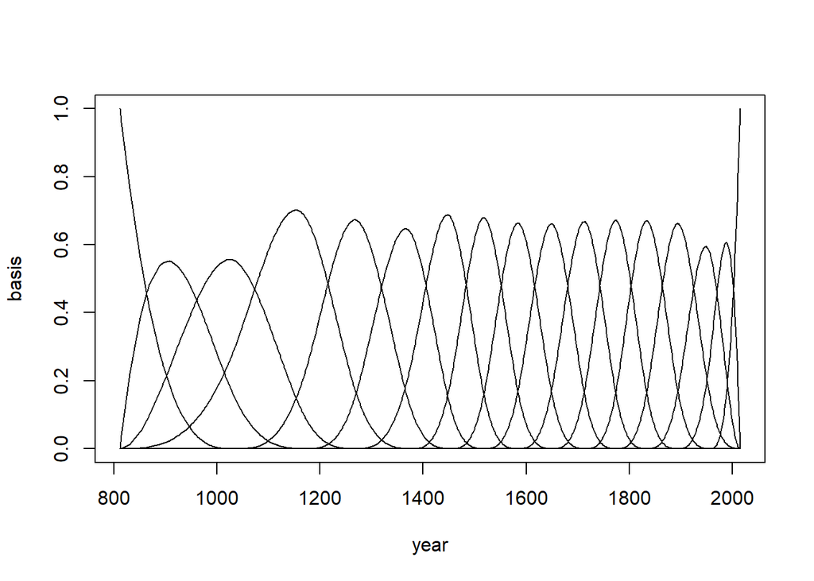

```r
library(splines)
splB15 <- bs(cd$year,
            knots = knot_list[-c(1, num_knots)],
            degree = 3, intercept = TRUE)

plot (NULL, xlim = range(cd$year), ylim = c(0, 1), xlab = "year", ylab = "basis")
for (i in 1:ncol(splB15)) lines(cd$year, splB15[, i])
```

Well I would use ggplot2 anyways. Let’s try using the geom_smooth functionality. **Note** The default degree for *bs* is 3. If I try specifying *knots* as *num_knots*, it does something strange. So instead I specify *df* as *num_knots*, and it ‘works’.

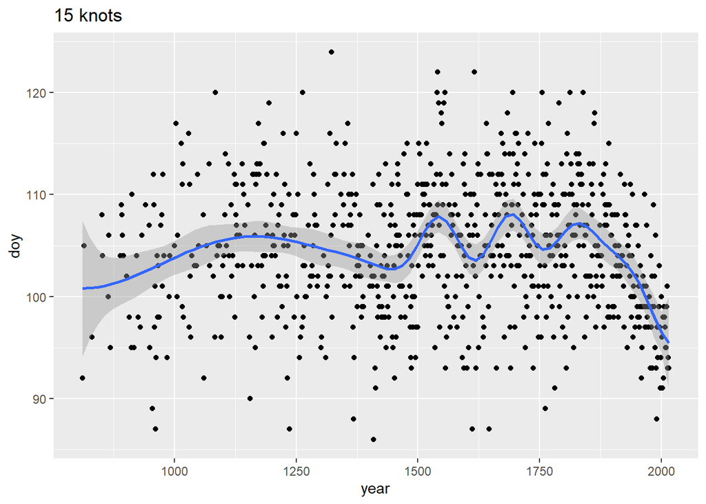

```r
ggplot(cd, aes(year, doy)) +
  geom_point() +
  geom_smooth(method = lm, formula = y ~ splines::bs(x, df = num_knots, degree = 3)) +
  labs(title = "15 knots")
```

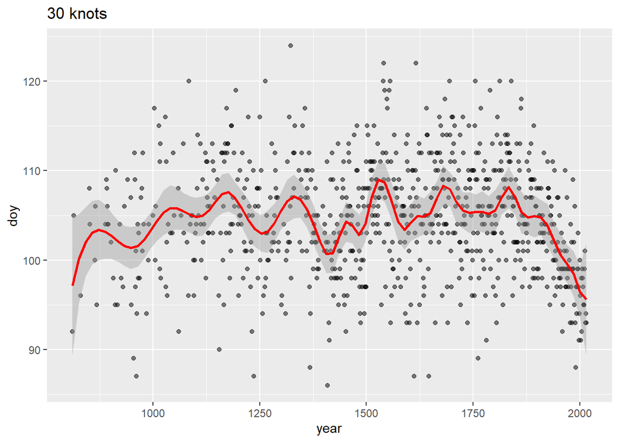

```r
ggplot(cd, aes(year, doy)) +
  geom_point(alpha = 0.5) +
  geom_smooth(method = lm, formula = y ~ splines::bs(x, df = num_knots*2, degree = 3), color = "red") +
  labs(title = "30 knots")
```

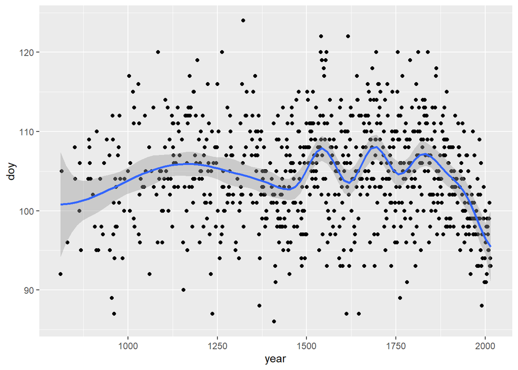

```r
ggplot(cd, aes(year, doy)) +
  geom_point() +
  geom_smooth(method = lm, formula = y ~ splines::bs(x, num_knots))
```

Use quap, not sure how to translate this plot into ggplot2. It seems the *se* argument in *geom_smooth* matches these though.

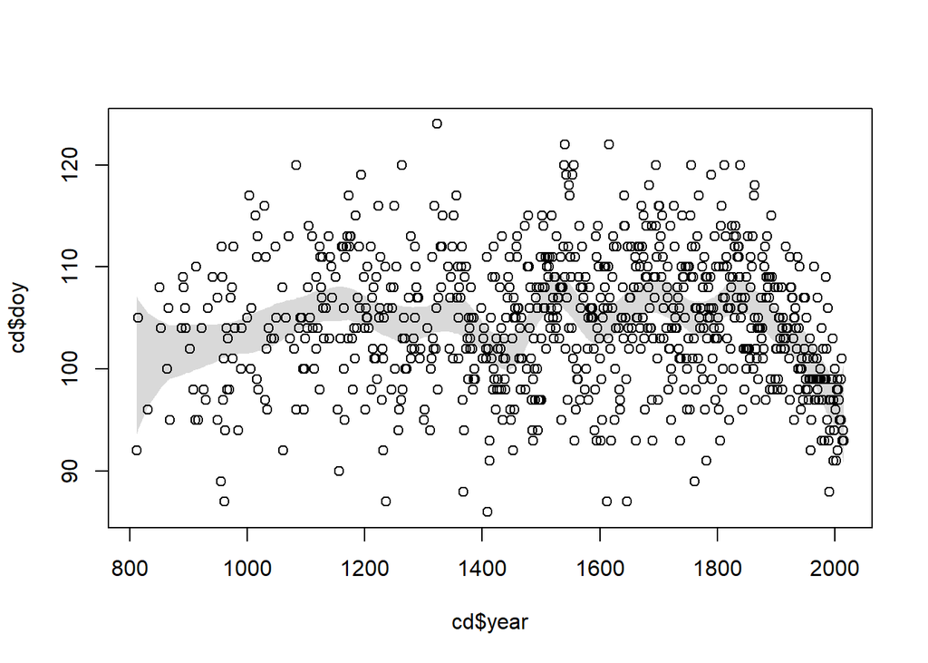

```r
spl_mod <-
  quap(
    alist(
      D ~ dnorm(mu, sigma),
      mu <- a + B %*% w,
      a ~ dnorm(100, 10),
      w ~ dnorm(0, 10),
      sigma ~ dexp(1)
    ), data = list(D = cd$doy, B = splB15),
    start = list(w = rep(0, ncol(splB15)))
  )

mu <- link(spl_mod)
mu_PI <- apply(mu, 2, PI, 0.97)
plot(cd$year, cd$doy)
shade(mu_PI, cd$year)
```